# Homework 11

Solutions will be available after Monday, November 9, 2026.

## Question 1: Implementing K-means

K-means is a relatively simple algorithm that we can write ourselves. For Questions 1 and 2, do not use an existing function that performs K-means directly.

Generate 10 observations with two independent standard normal coordinates. Set a random seed and report it. Randomly assign the observations to $K=2$ clusters, making sure neither cluster is empty. Let $C(i)$ denote the cluster assigned to observation $x_i$, and let $m_k$ denote the mean of cluster $k$.

1. Perform one iteration: calculate the cluster means, then assign each observation to its closest mean using Euclidean distance. Report the means and updated assignments, and plot the observations colored by their updated assignments.

```r
set.seed(123)
x <- matrix(rnorm(20), 10, 2)
g <- sample(rep(1:2, each = 5))
m <- rbind(colMeans(x[g == 1, ]), colMeans(x[g == 2, ]))
d1 <- rowSums(sweep(x, 2, m[1, ])^2)
d2 <- rowSums(sweep(x, 2, m[2, ])^2)
g <- ifelse(d1 <= d2, 1, 2)

m
```

```
           [,1]      [,2]
[1,]  0.6354249  0.566210
[2,] -0.4861736 -0.148966
```

```r
g
```

```
 [1] 1 2 1 2 2 1 1 2 2 2
```

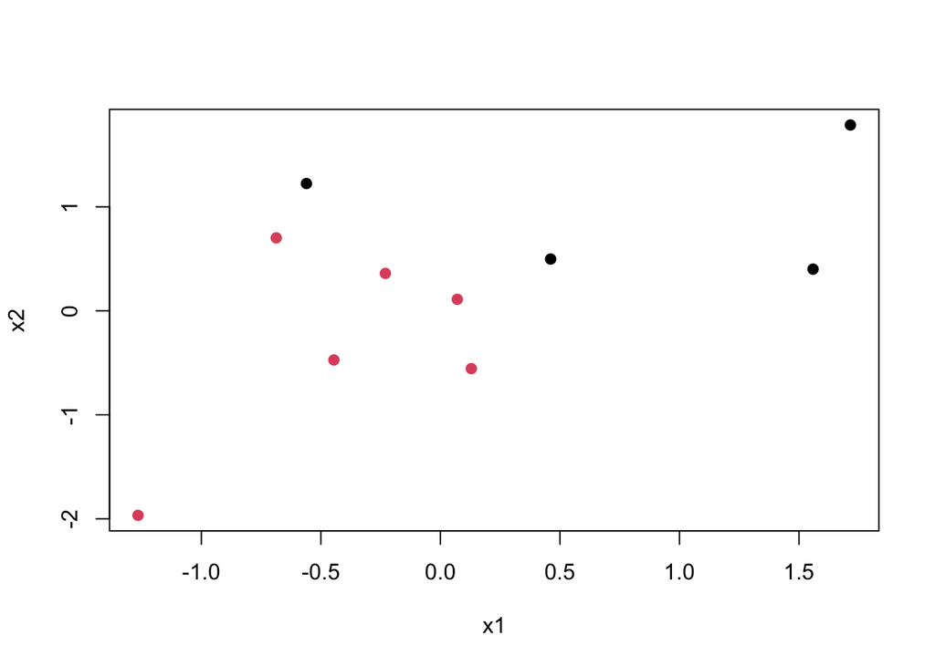

```r
plot(x, col = g, pch = 19, xlab = "x1", ylab = "x2")
```

Using seed 123, I computed the initial cluster means and reassigned each observation to its nearest mean using Euclidean distance. After one iteration, cluster 1 contains observations 1, 3, 6, and 7. Cluster 2 contains the remaining observations.

2. Write a function that repeats these two steps until the assignments stop changing or a specified maximum number of iterations is reached. Your function should work for a data matrix with any number of variables and a chosen number of clusters $K$. Start from a nonempty assignment to each cluster; if a cluster becomes empty during iteration, keep its previous mean. Recalculate the cluster means from the final assignments before returning them. Return the final assignments, cluster means, and within-cluster sum of squares,

   $$\sum_{k=1}^K\sum_{i:\,C(i)=k}\lVert x_i-m_k\rVert^2.$$

```r
my_kmeans <- function(x, K, max_iter = 100) {
  g <- sample(rep(1:K, length.out = nrow(x)))
  m <- matrix(0, K, ncol(x))

  for (i in 0:max_iter) {
    for (k in 1:K)
      if (any(g == k))
        m[k, ] <- colMeans(x[g == k, , drop = FALSE])

    if (i == max_iter) break

    d <- sapply(1:K, function(k)
      rowSums(sweep(x, 2, m[k, ])^2))
    new_g <- max.col(-d, ties.method = "first")

    if (all(new_g == g)) break
    g <- new_g
  }

  list(cluster = g, means = m,
       wss = sum((x - m[g, , drop = FALSE])^2))
}

my_kmeans(x, K = 2)
```

```
$cluster
 [1] 2 2 2 2 1 2 2 1 2 1

$means
           [,1]       [,2]
[1,] -0.5271452 -0.9984166
[2,]  0.3325274  0.7259242

$wss
[1] 10.08969
```

The function alternates between updating cluster means and reassigning observations until assignments stop changing or the iteration limit is reached. Empty clusters retain their previous means. It returns the final assignments, recalculated cluster means, and total within-cluster sum of squares.

3. Apply your function to the same 10 observations from two different random initial assignments. Report the final plots, cluster means, and within-cluster sums of squares. Do the two runs produce the same grouping and objective value? Explain your findings.

```r
set.seed(1)
r1 <- my_kmeans(x, 2)

set.seed(2)
r2 <- my_kmeans(x, 2)

r1
```

```
$cluster
 [1] 1 2 1 2 2 1 1 2 2 2

$means
           [,1]       [,2]
[1,]  0.7935535  0.9774042
[2,] -0.4046596 -0.3038995

$wss
[1] 10.49981
```

```r
r2
```

```
$cluster
 [1] 1 2 1 2 2 1 1 2 1 2

$means
           [,1]       [,2]
[1,]  0.4974722  0.9221946
[2,] -0.3482209 -0.5049506

$wss
[1] 11.00585
```

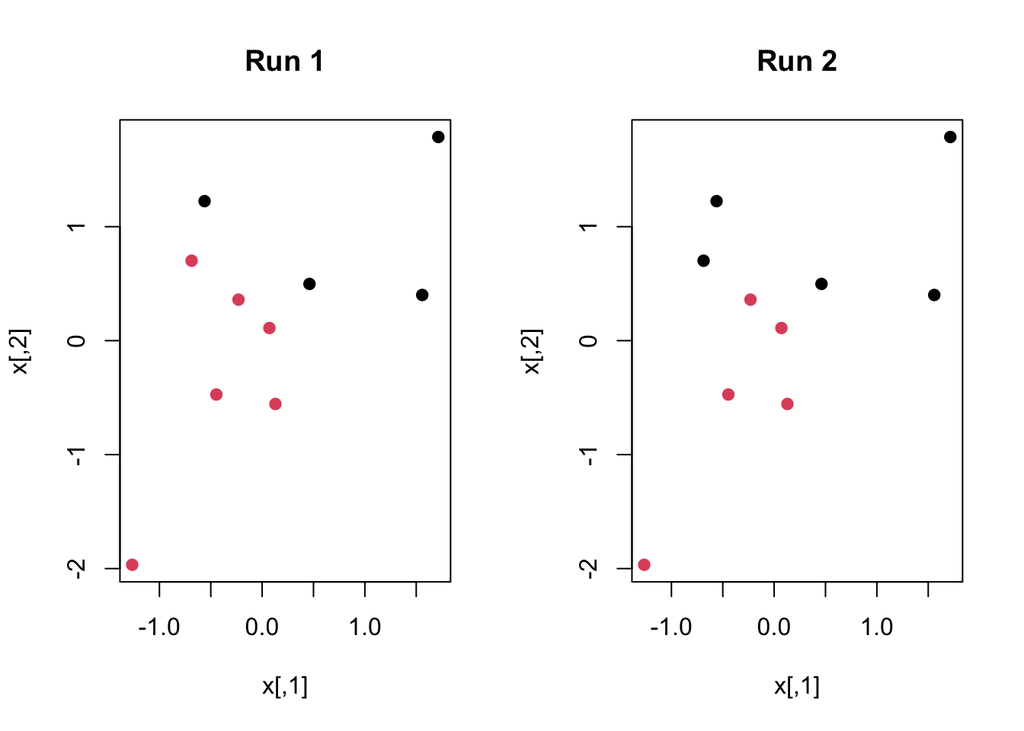

```r
par(mfrow = c(1, 2))
plot(x, col = r1$cluster, pch = 19, main = "Run 1")
plot(x, col = r2$cluster, pch = 19, main = "Run 2")
```

```r
par(mfrow = c(1, 1))

r2
```

```
$cluster
 [1] 1 2 1 2 2 1 1 2 1 2

$means
           [,1]       [,2]
[1,]  0.4974722  0.9221946
[2,] -0.3482209 -0.5049506

$wss
[1] 11.00585
```

The two runs produce different groupings and objective values. Observation 9 belongs to cluster 2 in Run 1 but cluster 1 in Run 2. The within-cluster sums of squares are 10.49981 and 11.00585, respectively, so Run 1 gives the better solution. This illustrates that K-means can converge to different local minima depending on the initial assignments.

## Question 2: Image color compression

Pick your favorite color image and use your K-means function from Question 1 to cluster its pixels. For computational efficiency, resize the image to no more than $200\times200$ pixels and use its three RGB color channels.

1. Plot the original image and report its dimensions. Transform it into a data matrix with one observation per pixel and three variables: red, green, and blue. Report the dimensions of this matrix.

```r
library(magick)
img <- image_read("/Users/tangshiyu/Desktop/stat432-fall2026/homework/week-11/data/IMG_2710.JPG")
image_info(img)[, c("width", "height")]
```

```
  width height
1  5712   4284
```

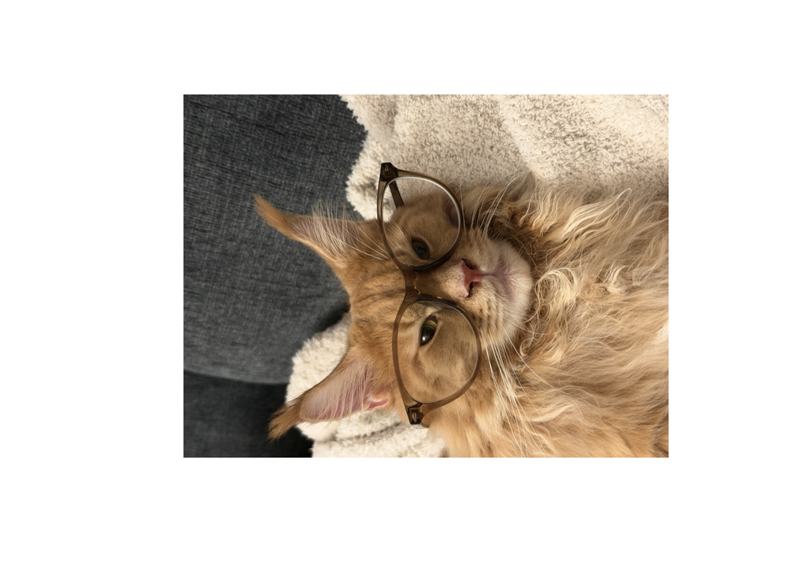

```r
plot(img)
```

```r
img <- image_resize(img, "200x200>")
rgb <- image_data(img, channels = "rgb")
pixels <- cbind(
  red = as.integer(rgb[1, , ]),
  green = as.integer(rgb[2, , ]),
  blue = as.integer(rgb[3, , ])
)
colnames(pixels) <- c("red", "green", "blue")

image_info(img)[, c("width", "height")]
```

```
  width height
1   200    150
```

```r
dim(pixels)
```

```
[1] 30000     3
```

The original image is 5712 × 4284 pixels. After resizing to 200 × 150 pixels, the pixel data matrix has 30000 rows and 3 columns, representing the red, green, and blue channels.

2. For $K=2,3,5,10$, apply your function to the pixel data. Report the cluster means and within-cluster sum of squares for each $K$. Reconstruct and plot each compressed image by replacing every pixel with its assigned cluster mean. Use the same RGB scale for all fits.

```
K = 2
          [,1]     [,2]      [,3]
[1,]  95.87937  84.3319  71.20789
[2,] 206.46841 180.0111 150.16956
[1] 76802475
```

```
K = 3
          [,1]      [,2]      [,3]
[1,] 225.25172 204.38575 178.41817
[2,] 178.87399 146.57472 112.84797
[3,]  85.16091  77.51624  68.17595
[1] 40623856
```

```
K = 5
          [,1]      [,2]      [,3]
[1,] 167.07477 133.82620  99.61863
[2,] 234.02186 217.86488 195.99875
[3,]  97.57735  89.41919  79.33391
[4,] 203.90444 174.49206 141.97598
[5,]  60.93268  55.09073  47.94463
[1] 20316521
```

```
K = 10
           [,1]      [,2]      [,3]
 [1,] 223.73085 203.21553 177.08322
 [2,]  93.78382  94.10206  91.54192
 [3,] 143.00894 110.74807  77.84437
 [4,] 170.14507 136.53775 102.06451
 [5,]  69.80120  70.69394  69.09753
 [6,] 190.85936 158.90099 125.12562
 [7,] 108.83386  77.67586  47.31787
 [8,] 209.17082 180.52291 148.31008
 [9,] 241.61849 228.33761 209.37179
[10,]  45.70513  36.31268  26.74359
[1] 8055573
```

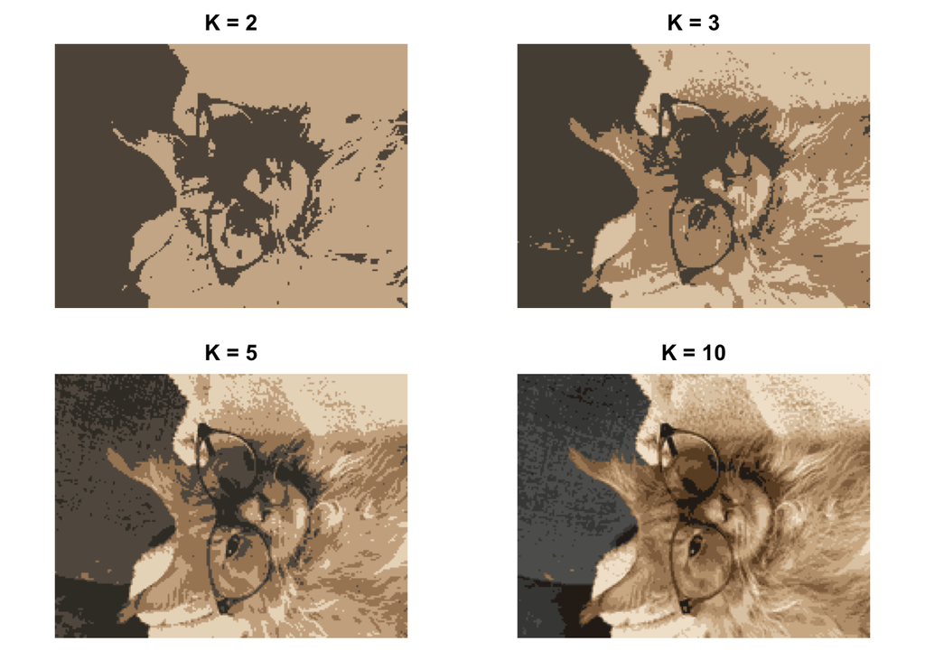

```r
set.seed(123)
par(mfrow = c(2, 2), mar = c(1, 1, 2, 1))

for (K in c(2, 3, 5, 10)) {
  fit <- my_kmeans(pixels, K)

  cat("\nK =", K, "\n")
  print(fit$means)
  print(fit$wss)

  compressed <- rgb
  for (j in 1:3) {
  compressed[j, , ] <-
  as.raw(round(fit$means[fit$cluster, j]))
  }
  plot(image_read(compressed))
  title(paste("K =", K))
}
```

```r
par(mfrow = c(1, 1))
```

3. Which value of $K$ would you choose for this image? Briefly justify your choice using the reconstructed images and the within-cluster sums of squares.

I would choose K = 10 because it preserves more detail in the cat’s fur, glasses, and background while using only 10 colors. The within-cluster sum of squares decreases from 20,316,521 at K = 5 to 8,055,573 at K = 10, a reduction of about 60%. This improvement justifies using the additional colors.

## Question 3: Hierarchical clustering of cars

The file `data/mtcars.csv` contains 11 numerical variables for 32 cars, including fuel economy, horsepower, and weight. The `car` column gives the model names; use it to label observations, not as a clustering variable. You may use existing hierarchical clustering functions for this question.

1. Standardize each numerical variable to have mean 0 and standard deviation 1. Using Euclidean distance, perform hierarchical clustering with single, complete, and average linkage. Plot the three dendrograms with the car names and compare the results.

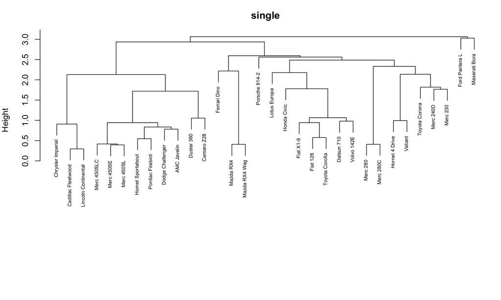

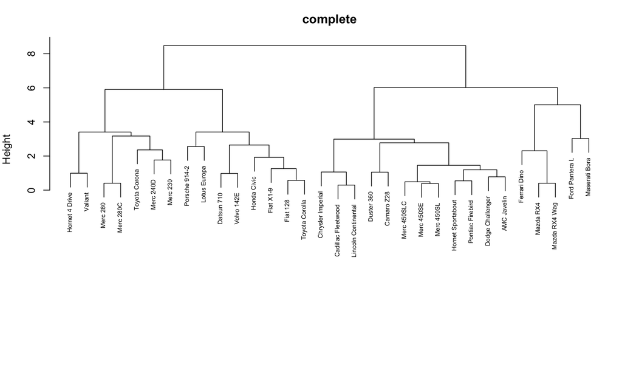

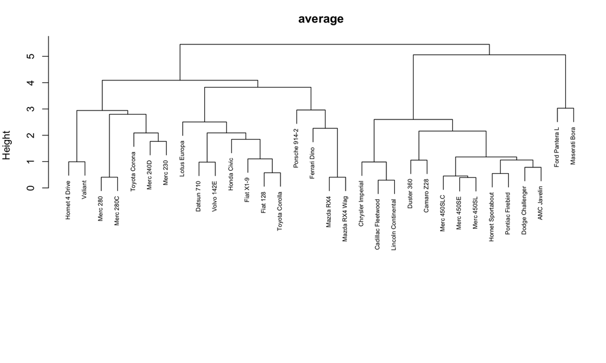

```r
par(mfrow = c(1, 1), mar = c(9, 4, 3, 1))

cars <- read.csv(
  "/Users/tangshiyu/Desktop/stat432-fall2026/homework/week-11/data/mtcars.csv",
  row.names = "car"
)

z <- scale(cars)
d <- dist(z, method = "euclidean")

for (method in c("single", "complete", "average")) {
  hc <- hclust(d, method = method)
  plot(hc, main = method, xlab = "", sub = "", cex = 0.6)
}
```

Single linkage shows a chaining pattern, with cars or small groups joining larger clusters at similar heights. Complete linkage produces more clearly separated groups, while average linkage gives an intermediate structure. Some close pairs, such as Mazda RX4 and Mazda RX4 Wag, remain together across all three methods. However, larger groupings differ: the Mazda pair joins the Ferrari Dino and then the Porsche 914-2 under average linkage, whereas under complete linkage it joins the Ferrari Dino and then the Ford Pantera L–Maserati Bora group.

2. Choose one linkage method and a number of clusters that you consider reasonable. Report the cluster memberships and a table of cluster means on the original variable scales. Describe the main characteristics of the groups and explain your choice using the dendrogram and table. Briefly explain why standardizing the variables matters for this analysis.

```r
hc <- hclust(d, method = "complete")
g <- cutree(hc, k = 3)

split(rownames(cars), g)
```

```
$`1`
[1] "Mazda RX4"      "Mazda RX4 Wag"  "Ford Pantera L" "Ferrari Dino"
[5] "Maserati Bora"

$`2`
 [1] "Datsun 710"     "Hornet 4 Drive" "Valiant"        "Merc 240D"
 [5] "Merc 230"       "Merc 280"       "Merc 280C"      "Fiat 128"
 [9] "Honda Civic"    "Toyota Corolla" "Toyota Corona"  "Fiat X1-9"
[13] "Porsche 914-2"  "Lotus Europa"   "Volvo 142E"

$`3`
 [1] "Hornet Sportabout"   "Duster 360"          "Merc 450SE"
 [4] "Merc 450SL"          "Merc 450SLC"         "Cadillac Fleetwood"
 [7] "Lincoln Continental" "Chrysler Imperial"   "Dodge Challenger"
[10] "AMC Javelin"         "Camaro Z28"          "Pontiac Firebird"
```

```r
round(aggregate(cars, by = list(cluster = g), FUN = mean), 2)
```

```
  cluster   mpg  cyl   disp     hp drat   wt  qsec   vs   am gear carb
1       1 18.50 6.80 223.40 198.80 3.84 3.00 15.62 0.00 1.00 4.60 5.20
2       2 24.65 4.53 131.65  91.33 3.90 2.58 19.16 0.93 0.53 3.93 1.80
3       3 15.05 8.00 357.62 194.17 3.12 4.10 17.14 0.00 0.00 3.00 3.08
```

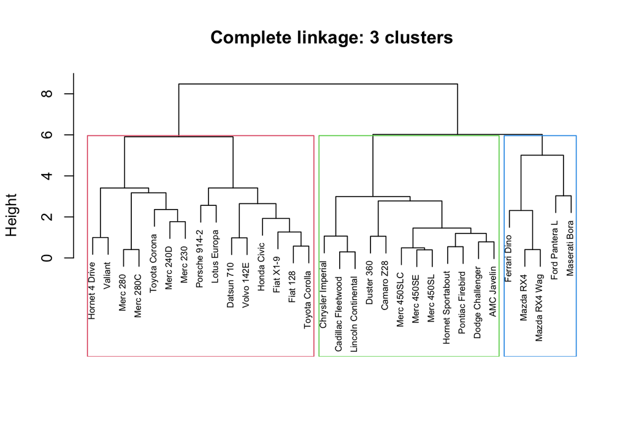

```r
plot(hc, main = "Complete linkage: 3 clusters",
     xlab = "", sub = "", cex = 0.6)
rect.hclust(hc, k = 3, border = 2:4)
```

I chose complete linkage with three clusters because it avoids the chaining seen with single linkage and produces interpretable groups. Cutting the dendrogram just below height 6 gives these three clusters, although the larger gap above 6 also supports a two-cluster solution.

Cluster 1 contains 5 cars, all with manual transmissions, averaging 198.80 horsepower and a quarter-mile time of 15.62 seconds, suggesting a performance-oriented group. Cluster 2 contains 15 generally lighter, more fuel-efficient cars, averaging 24.65 mpg, 91.33 horsepower, and a weight of 2.58 thousand pounds. Cluster 3 contains 12 heavier cars, all with eight cylinders and automatic transmissions, averaging 15.05 mpg and a weight of 4.10 thousand pounds.

Standardization matters because the variables have different units and scales. Without it, variables such as displacement and horsepower could dominate Euclidean distances. Scaling each variable to mean 0 and standard deviation 1 makes their contributions more comparable.